# Projeto final da disciplina de Estatística Experimental

Marcella Siqueira

Dados coletados diretamente do site: https://dadosabertos.camara.leg.br/swagger/api.html#staticfile

Para este projeto, foram coletados dados dos gastos de deputados federais de todo o Brasil durante o período de 2017 a 2022. Após limpeza dos dados, contamos com atributos de:

- Nome do parlamentar
- CPF do parlamentar
- Estado do parlamentar
- Partido do parlamentar
- Descrição do gasto do parlamentar
- Fornecedor referente ao gasto
- Data da emissão da nota do gasto
- Valor bruto do documento
- Valor de glosa do documento
- Valor líquido do documento
- Mês referente ao gasto
- Ano referente ao gasto

Inicialmente foi realizada uma análise exploratória a partir desta base de dados.

```r
dados <- list.files(path = "dados/",
                       pattern = "*.csv", full.names = TRUE) %>%
  lapply(read_csv) %>%
  bind_rows
```

```r
dados <- dados %>%
  select(-ideCadastro, -nuCarteiraParlamentar, -nuLegislatura, -codLegislatura, -numSubCota, -numEspecificacaoSubCota, -txtDescricaoEspecificacao, -txtCNPJCPF, -txtNumero, -indTipoDocumento, -numParcela, -txtPassageiro, -txtTrecho, -numLote, -numRessarcimento, -vlrRestituicao, -datPagamentoRestituicao, -nuDeputadoId, -ideDocumento, -urlDocumento) %>%
  filter(!is.na(sgUF)) %>%
  filter(!is.na(sgPartido)) %>%
  filter(vlrLiquido > 0)
```

## Quanto os nossos deputados gastaram anualmente?

Aqui buscamos visualizar o valor total dos gastos dos deputados a cada ano coletado. Temos sempre valores na casa dos 200 milhões, sendo a única exceção o ano de 2020, em que o gasto cai para menos de 180 milhões, sendo este o ano de início da pandemia. Nos anos seguintes o gasto volta a subir.

```r
por_ano <- dados %>%
  group_by(numAno) %>%
  summarise(total_ano = sum(vlrLiquido))
```

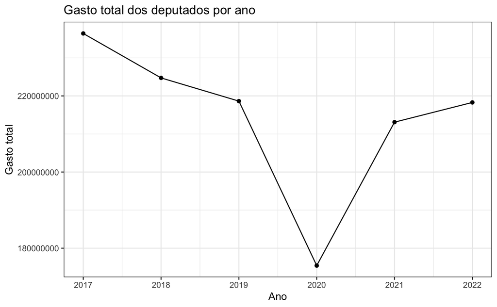

```r
por_ano %>%
  tail(12) %>%
  ggplot(aes(x=numAno, y=total_ano)) +
    geom_line() +
    geom_point() +
  # scale_y_continuous(breaks = c(170000000, 180000000,190000000,200000000,210000000,220000000,230000000,240000000,250000000)) +
  scale_x_continuous(breaks=c(2017,2018,2019,2020,2021,2022)) +
  labs(
    x = "Ano",
    y = "Gasto total",
    title = "Gasto total dos deputados por ano"
  )
```

## Quanto os nossos deputados gastam por ano?

```r
deputado_ano <- dados %>%
  group_by(txNomeParlamentar, numAno) %>%
  summarise(total_deputado = sum(vlrLiquido),
              .groups = "drop")
```

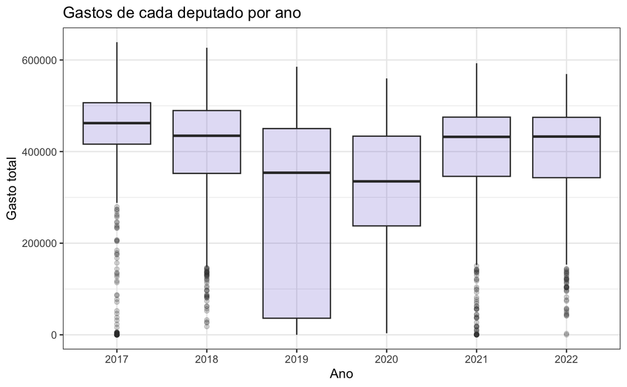

```r
deputado_ano %>%
  ggplot(aes(x=as.factor(numAno), y=total_deputado)) +
    geom_boxplot(fill="slateblue", alpha=0.2) +
  labs(
    x = "Ano",
    y = "Gasto total",
    title = "Gastos de cada deputado por ano"
  )
```

## Qual partido gasta mais?

Procuramos entender agora quais os partidos que mais tiveram gastos nestes anos analisados. Uma importante verificação é a de quantos deputados cada um desses partidos tem como representantes na Câmara.

```r
por_partido <- dados %>%
  group_by(sgPartido) %>%
  summarise(total_partido = sum(vlrLiquido))
```

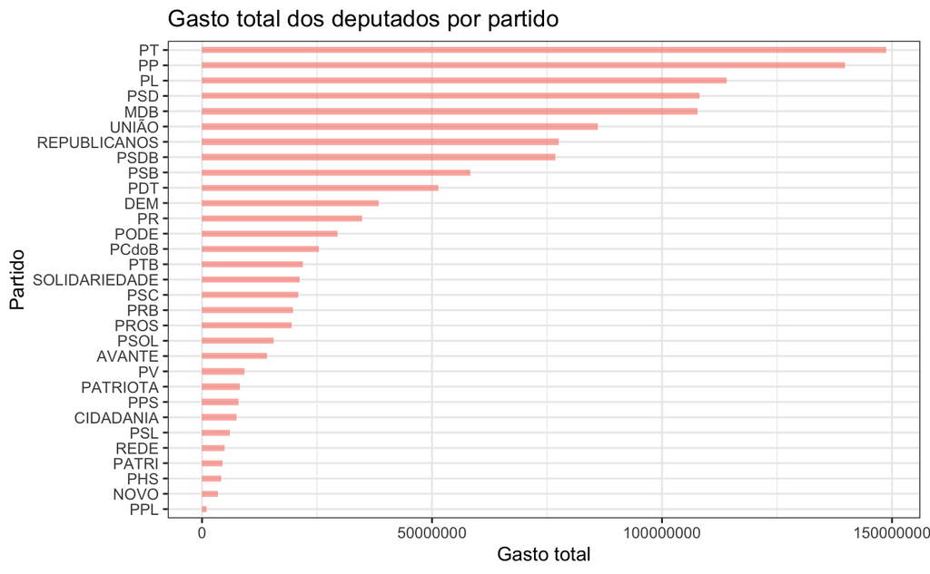

```r
por_partido %>%
  mutate(partido = fct_reorder(sgPartido, total_partido)) %>%
  # tail(10) %>%
  ggplot(aes(x=partido, y=total_partido)) +
    geom_bar(stat="identity", fill="salmon", alpha=.6, width=.4) +
    coord_flip()  +
  # scale_y_continuous(breaks = seq(20000, 20000000, by = 2000000)) +
  labs(
    x = "Partido",
    y = "Gasto total",
    title = "Gasto total dos deputados por partido"
  )
```

## Quantos deputados temos por partido?

```r
deputados_partido <- dados %>%
    filter(!is.na(sgPartido)) %>%
    group_by(sgPartido) %>%
    summarise(deputados = n_distinct(cpf),
              .groups = "drop") %>%
  arrange(desc(deputados)) %>%    # First sort by val. This sort the dataframe but NOT the factor levels
  mutate(sgPartido=factor(sgPartido, levels=sgPartido))  # This trick update the factor levels
```

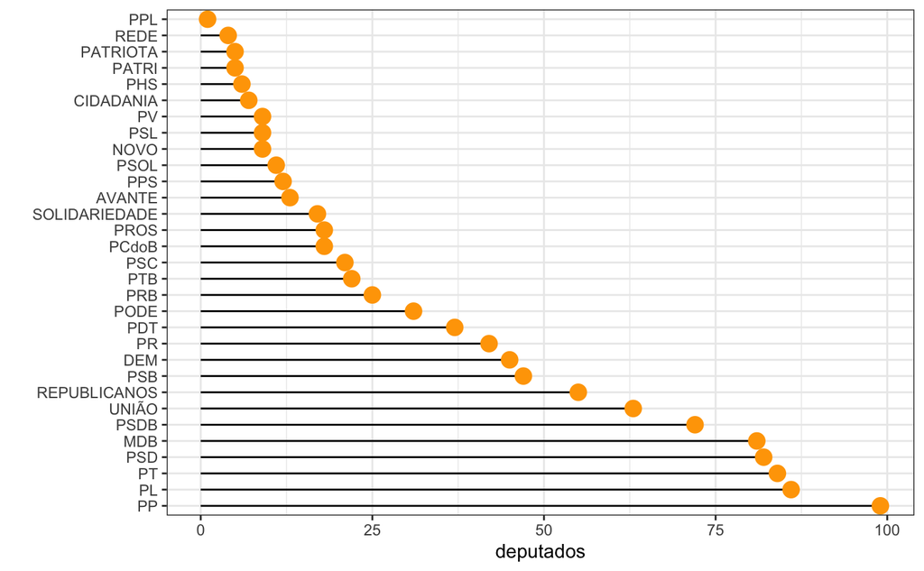

```r
deputados_partido %>%
  # arrange(deputados) %>%    # First sort by val. This sort the dataframe but NOT the factor levels
  # mutate(sgPartido=factor(sgPartido, levels=sgPartido)) %>%   # This trick update the factor levels
  ggplot(aes(x=sgPartido, y=deputados)) +
    geom_segment(aes(xend=sgPartido, yend=0)) +
    geom_point(size=4, color="orange") +
    coord_flip() +
    theme_bw() +
    xlab("")
```

```r
# Set a number of 'empty bar'
empty_bar <- 10

# Add lines to the initial dataset
to_add <- matrix(NA, empty_bar, ncol(deputados_partido))
colnames(to_add) <- colnames(deputados_partido)
deputados_partido <- rbind(deputados_partido, to_add)
deputados_partido$id <- seq(1, nrow(deputados_partido))

# Get the name and the y position of each label
label_data <- deputados_partido
number_of_bar <- nrow(label_data)
angle <- 90 - 360 * (label_data$id-0.5) /number_of_bar     # I substract 0.5 because the letter must have the angle of the center of the bars. Not extreme right(1) or extreme left (0)
label_data$hjust <- ifelse( angle < -90, 1, 0)
label_data$angle <- ifelse(angle < -90, angle+180, angle)
label_data$sgPartido <- paste(label_data$sgPartido, " (", label_data$deputados,")", sep="")
```

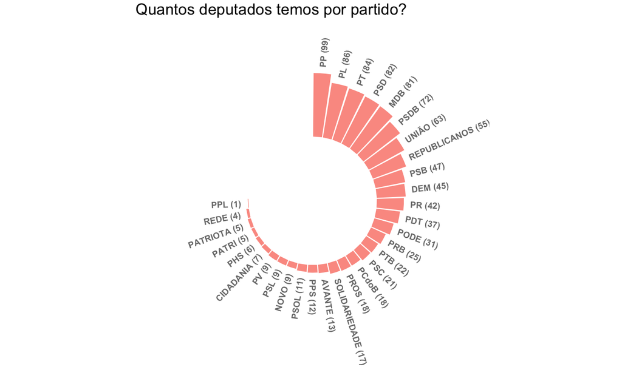

```r
deputados_partido %>%
  ggplot(aes(x=as.factor(id), y=deputados)) +       # Note that id is a factor. If x is numeric, there is some space between the first bar
  geom_bar(stat="identity", fill=alpha("salmon", 0.8)) +
  ylim(-100,120) +
  theme_minimal() +
  theme(
    axis.text = element_blank(),
    axis.title = element_blank(),
    panel.grid = element_blank(),
    plot.margin = unit(rep(0.1,4), "cm")
  ) +
  coord_polar(start = 0) +
  geom_text(data=label_data, aes(x=id, y=deputados+10, label=sgPartido, hjust=hjust), color="black", fontface="bold",alpha=0.6, size=2.6, angle= label_data$angle, inherit.aes = FALSE ) +
  labs(title = "Quantos deputados temos por partido?")
```

## Com o que os deputados gastam mais?

Tendo acesso às categorias dos gastos dos deputados, buscamos entender quais seriam seus maiores gastos. Temos **divulgação da atividade parlamentar**, **passagem aérea** e **locação ou fretamento de veículos automotores** sendo as categorias em que mais gastaram.

```r
por_categoria <- dados %>%
  group_by(txtDescricao) %>%
  summarise(total_categoria = sum(vlrLiquido))
```

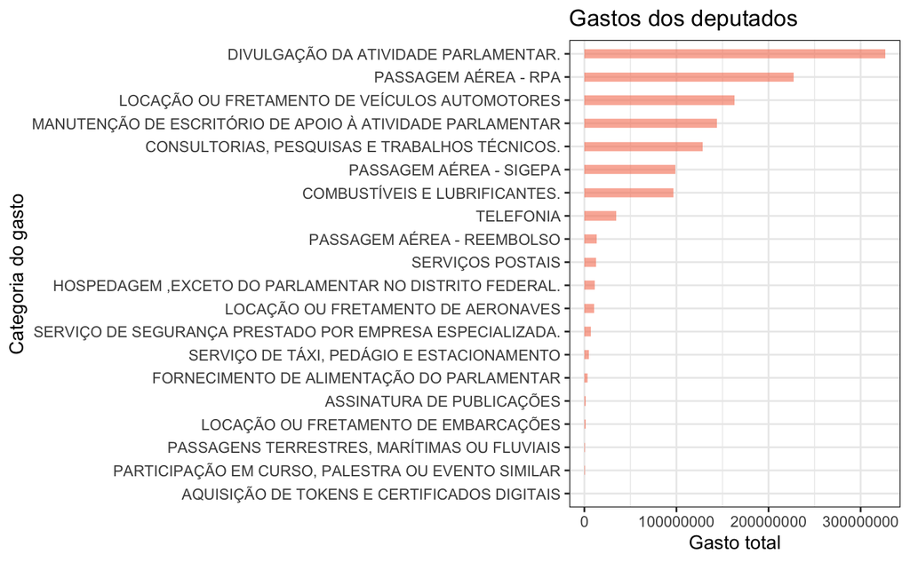

```r
por_categoria %>%
  mutate(categoria = fct_reorder(txtDescricao, total_categoria)) %>%
  ggplot(aes(x=categoria, y=total_categoria)) +
    geom_bar(stat="identity", fill="#f68060", alpha=.6, width=.4) +
    coord_flip()  +
  # scale_y_continuous(breaks = seq(20000, 20000000, by = 2000000)) +
  labs(
    x = "Categoria do gasto",
    y = "Gasto total",
    title = "Gastos dos deputados"
  )
```

## Como esses gastos se distribuem?

Realizamos uma distribuição dos nossos dados através de um histograma e é visualmente perceptível que não estamos lidando com dados normais.

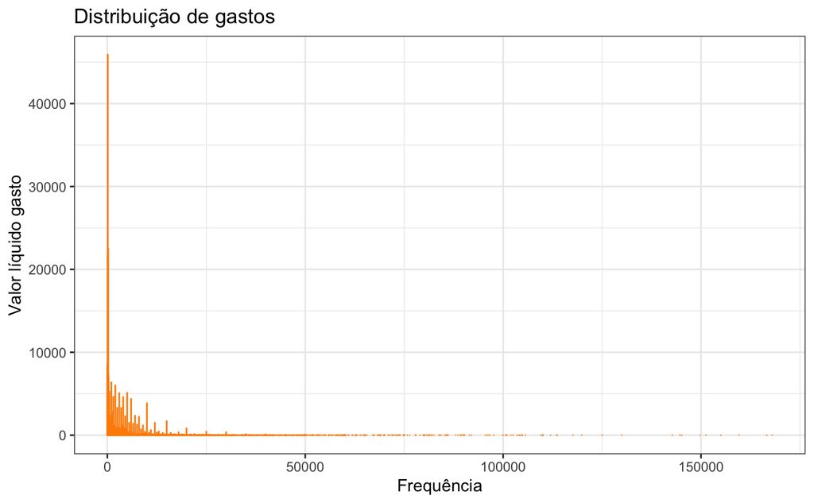

```r
dados %>%
  ggplot(aes(x = vlrLiquido)) +
  geom_histogram(binwidth = .5,
                 colour = "darkorange",
                 fill = "white") +
  labs(title = "Distribuição de gastos",
       x = "Frequência",
       y = "Valor líquido gasto")
```

## Quais regiões tiveram maiores gastos?

Observamos os gastos agora por regiões às quais os deputados pertenciam. Dois diferentes gráficos foram gerados para visualizarmos esse resultado.

```r
norte <- c("AM","RR","AP","PA","TO","RO","AC")
nordeste <- c("MA","PI","CE","RN","PE","PB","SE","AL","BA")
sudeste <- c("SP","RJ","ES","MG")
centro <- c("MT","MS","GO","DF")
sul <- c("PR","RS","SC")
```

```r
teste <- dados %>%
  mutate(regiao = case_when(sgUF %in% norte ~ "Norte",
                           sgUF %in% nordeste ~ "Nordeste",
                           sgUF %in% sudeste ~ "Sudeste",
                           sgUF %in% centro ~ "Centro-Oeste",
                           sgUF %in% sul ~ "Sul"))
```

```r
gasto_ano_regiao <- teste %>%
    group_by(regiao, numAno) %>%
    summarise(gasto = sum(vlrLiquido),
              .groups = "drop")
```

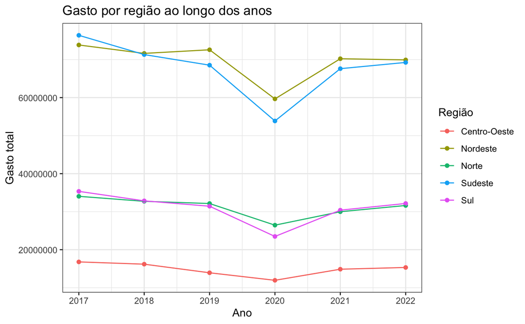

```r
gasto_ano_regiao %>%
  ggplot(aes(x = numAno, y = gasto, color = regiao)) +
    geom_point() +
    geom_line() +
  scale_x_continuous(breaks=c(2017,2018,2019,2020,2021,2022)) +
  labs(
    x = "Ano",
    y = "Gasto total",
    color = "Região",
    title = "Gasto por região ao longo dos anos"
  )
```

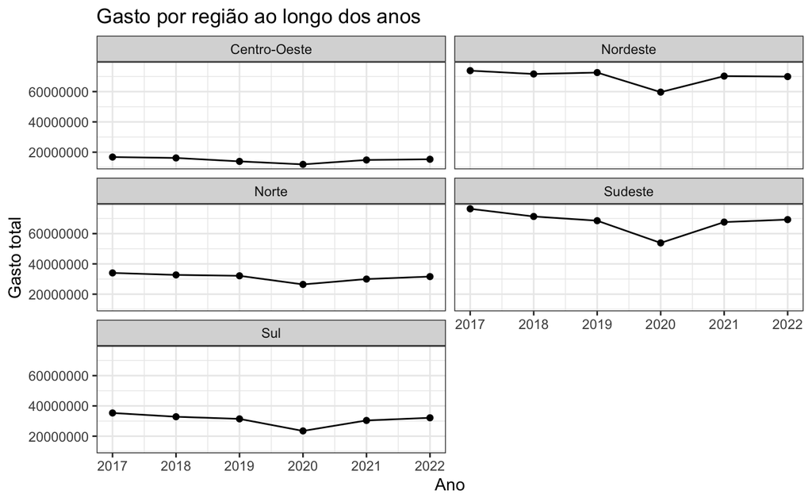

```r
gasto_ano_regiao %>%
  ggplot(aes(x = numAno, y = gasto)) +
    geom_point() +
    geom_line() +
  facet_wrap(~ regiao, ncol = 2) +
  scale_x_continuous(breaks=c(2017,2018,2019,2020,2021,2022)) +
  labs(
    x = "Ano",
    y = "Gasto total",
    title = "Gasto por região ao longo dos anos"
  )
```

## Quantos deputados temos por região?

```r
deputados_regiao <- teste %>%
    group_by(regiao) %>%
    summarise(deputados = n_distinct(cpf),
              .groups = "drop")
```

```r
deputados_regiao$fracao <- deputados_regiao$deputados / sum(deputados_regiao$deputados)
```

```r
deputados_regiao$ymax <- cumsum(deputados_regiao$fracao)
```

```r
deputados_regiao$ymin <- c(0, head(deputados_regiao$ymax, n=-1))
```

```r
deputados_regiao$labelPosition <- (deputados_regiao$ymax + deputados_regiao$ymin) / 2
```

```r
deputados_regiao$label <- paste0(deputados_regiao$regiao, "\n", deputados_regiao$deputados, " deputados")
```

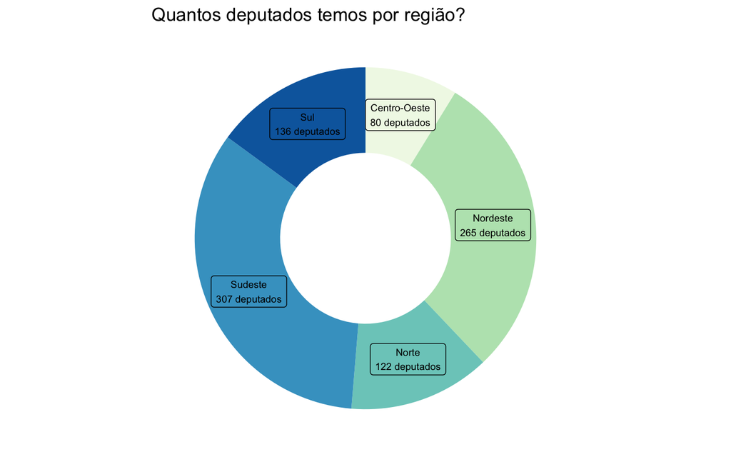

```r
deputados_regiao %>%
  ggplot(aes(ymax=ymax, ymin=ymin, xmax=4, xmin=3, fill=regiao)) +
  geom_rect() +
  geom_label(x=3.5, aes(y=labelPosition, label=label), size=2.5) +
  scale_fill_brewer(palette=4) +
  coord_polar(theta="y") +
  xlim(c(2, 4)) +
  theme_void() +
  theme(legend.position = "none") +
  labs(
    title = "Quantos deputados temos por região?"
  )
```

## Quanto se gastou durante a pandemia?

Procuramos entender se os gastos durante a pandemia se mantiveram semelhantes aos gastos no período pré pandemia ou se ocorreram mudanças neste sentido. Três diferentes visualizações foram geradas para observamos essa diferença com mais detalhes.

```r
pre_pandemia <- c(2017,2018,2019)
pandemia <- c(2020,2021,2022)
```

```r
teste2 <- dados %>%
  mutate(periodo = case_when(numAno %in% pre_pandemia ~ "Pré pandemia",
                           numAno %in% pandemia ~ "Pandemia"))
```

```r
gasto_periodo <- teste2 %>%
    group_by(periodo, numAno) %>%
    summarise(gasto = sum(vlrLiquido),
              .groups = "drop")
```

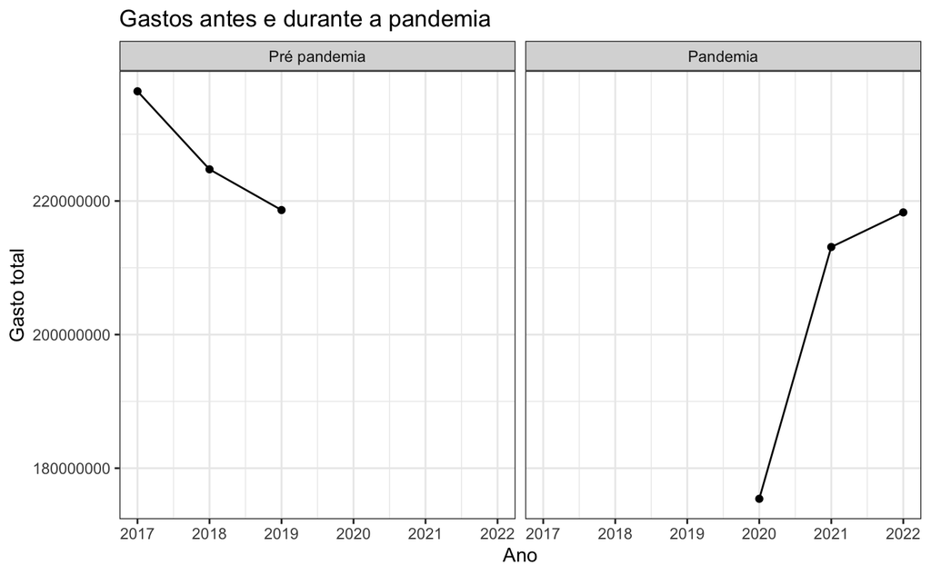

```r
gasto_periodo %>%
  ggplot(aes(x = numAno, y = gasto)) +
    geom_point() +
    geom_line() +
  facet_wrap(~factor(periodo, levels=c("Pré pandemia", "Pandemia")), ncol = 2) +
  scale_x_continuous(breaks=c(2017,2018,2019,2020,2021,2022)) +
  labs(
    x = "Ano",
    y = "Gasto total",
    title = "Gastos antes e durante a pandemia"
  )
```

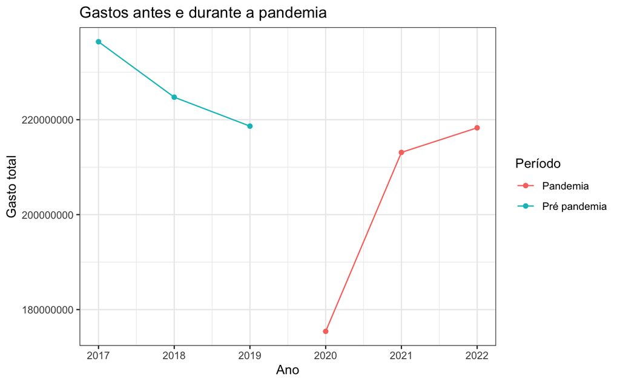

```r
gasto_periodo %>%
  ggplot(aes(x = numAno, y = gasto, color = periodo)) +
    geom_point() +
    geom_line() +
  scale_x_continuous(breaks=c(2017,2018,2019,2020,2021,2022)) +
  labs(
    x = "Ano",
    y = "Gasto total",
    color = "Período",
    title = "Gastos antes e durante a pandemia"
  )
```

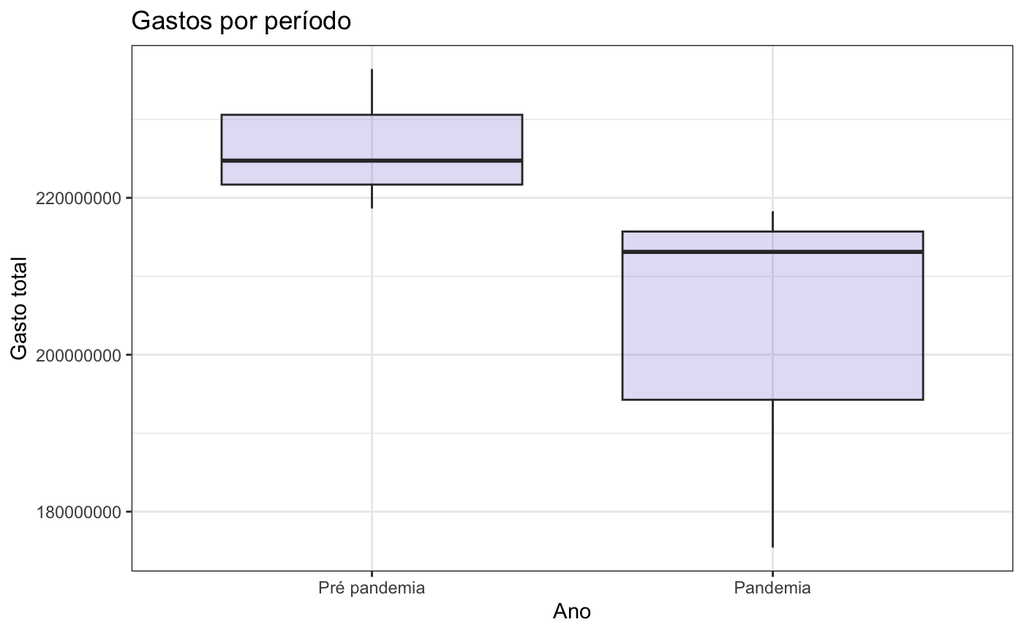

```r
gasto_periodo %>%
  arrange(gasto) %>%
  mutate(periodo = factor(periodo, levels=c("Pré pandemia", "Pandemia"))) %>%
  ggplot(aes(x=as.factor(periodo), y=gasto)) +
    geom_boxplot(fill="slateblue", alpha=0.2) +
  labs(
    x = "Ano",
    y = "Gasto total",
    title = "Gastos por período"
  )
```

### Quais os gastos dos deputados pré e durante a pandemia?

Buscamos entender se os gastos por categoria se mantiveram os mesmos durante estes diferentes períodos da nossa história recente. É perceptível o quanto os gastos com passagens aéreas foram reduzidos durante este período pandêmico.

```r
tipo_gasto_periodo <- teste2 %>%
  group_by(txtDescricao, periodo) %>%
  summarise(total_categoria = sum(vlrLiquido),
              .groups = "drop")
```

### Pré-pandemia

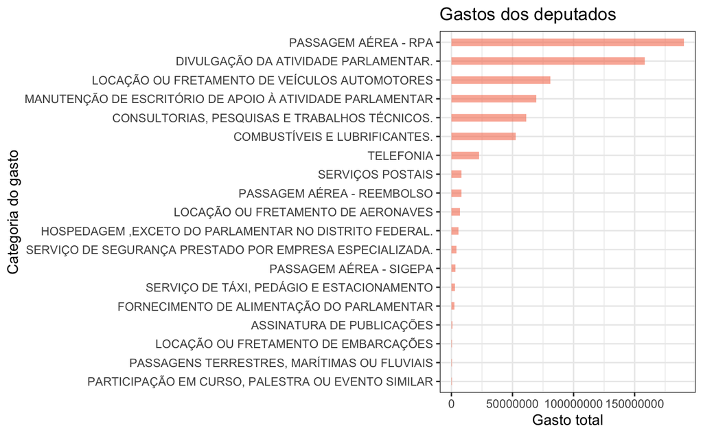

```r
tipo_gasto_periodo %>%
  filter(periodo == "Pré pandemia") %>%
  arrange(total_categoria) %>%
  mutate(txtDescricao = factor(txtDescricao, levels=txtDescricao)) %>%
  top_n(20, total_categoria) %>%
  ggplot(aes(x=txtDescricao, y=total_categoria)) +
    geom_bar(stat="identity", fill="#f68060", alpha=.6, width=.4) +
    coord_flip()  +
  # facet_wrap(~factor(periodo, levels=c("Pré pandemia", "Pandemia")), ncol = 1) +
  labs(
    x = "Categoria do gasto",
    y = "Gasto total",
    title = "Gastos dos deputados"
  )
```

### Durante a pandemia

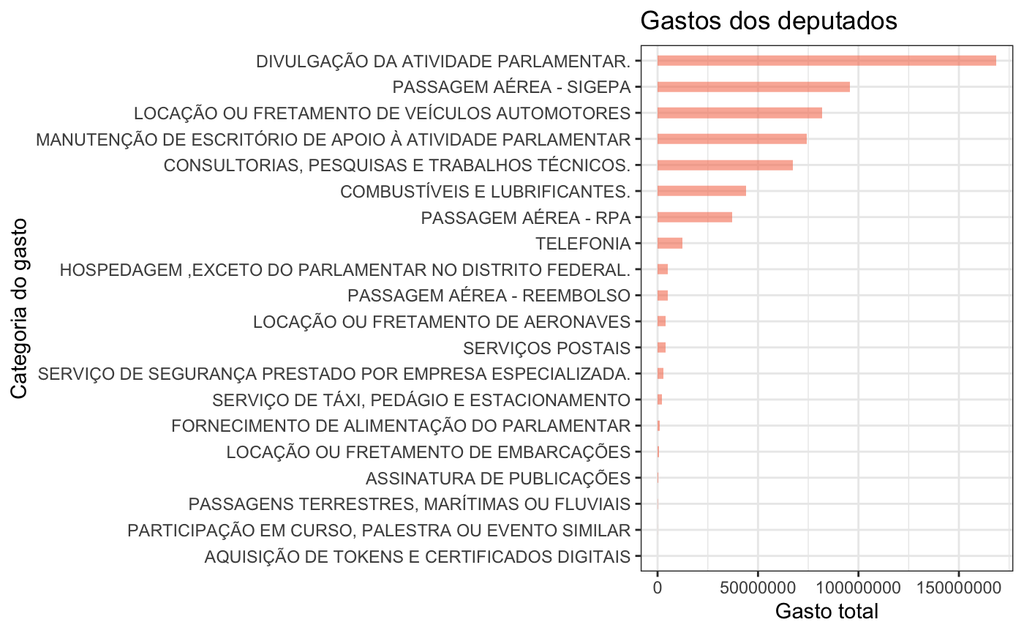

```r
tipo_gasto_periodo %>%
  filter(periodo == "Pandemia") %>%
  arrange(total_categoria) %>%
  mutate(txtDescricao = factor(txtDescricao, levels=txtDescricao)) %>%
  top_n(20, total_categoria) %>%
  ggplot(aes(x=txtDescricao, y=total_categoria)) +
    geom_bar(stat="identity", fill="#f68060", alpha=.6, width=.4) +
    coord_flip()  +
  # facet_wrap(~factor(periodo, levels=c("Pré pandemia", "Pandemia")), ncol = 1) +
  labs(
    x = "Categoria do gasto",
    y = "Gasto total",
    title = "Gastos dos deputados"
  )
```

## Quais deputados gastaram mais nos períodos pré e durante a pandemia?

```r
deputado_periodo <- teste2 %>%
  group_by(txNomeParlamentar, periodo) %>%
  summarise(total_deputado = sum(vlrLiquido),
              .groups = "drop")
```

### Pré-pandemia

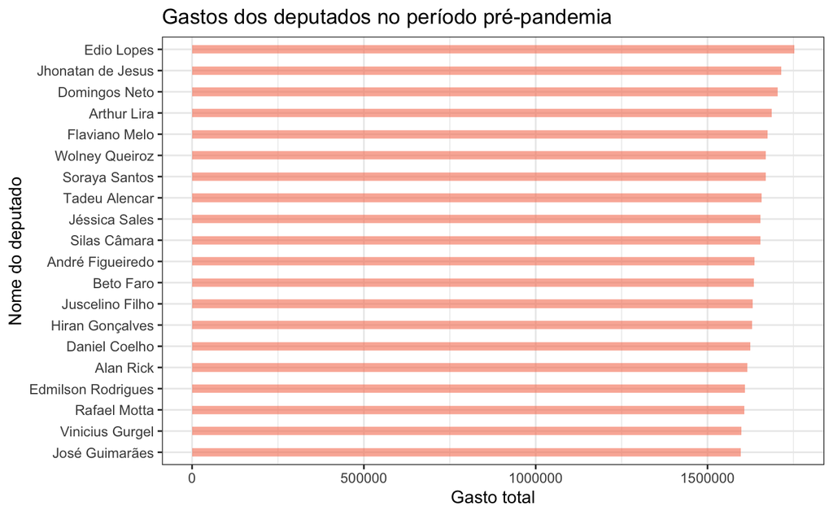

```r
deputado_periodo %>%
  filter(periodo == "Pré pandemia") %>%
  arrange(total_deputado) %>%
  mutate(txNomeParlamentar = factor(txNomeParlamentar, levels=txNomeParlamentar)) %>%
  top_n(20, total_deputado) %>%
  ggplot(aes(x=txNomeParlamentar, y=total_deputado)) +
    geom_bar(stat="identity", fill="#f68060", alpha=.6, width=.4) +
    coord_flip()  +
  # facet_wrap(~factor(periodo, levels=c("Pré pandemia", "Pandemia")), ncol = 1) +
  labs(
    x = "Nome do deputado",
    y = "Gasto total",
    title = "Gastos dos deputados no período pré-pandemia"
  )
```

### Durante a pandemia

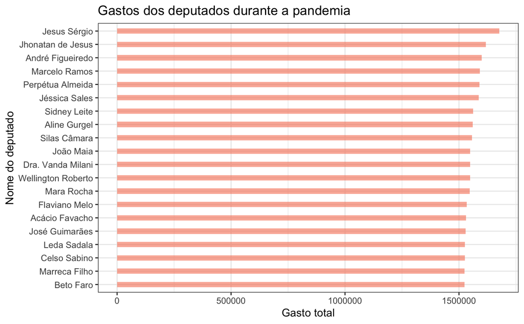

```r
deputado_periodo %>%
  filter(periodo == "Pandemia") %>%
  arrange(total_deputado) %>%
  mutate(txNomeParlamentar = factor(txNomeParlamentar, levels=txNomeParlamentar)) %>%
  top_n(20, total_deputado) %>%
  ggplot(aes(x=txNomeParlamentar, y=total_deputado)) +
    geom_bar(stat="identity", fill="#f68060", alpha=.6, width=.4) +
    coord_flip()  +
  # facet_wrap(~factor(periodo, levels=c("Pré pandemia", "Pandemia")), ncol = 1) +
  labs(
    x = "Nome do deputado",
    y = "Gasto total",
    title = "Gastos dos deputados durante a pandemia"
  )
```

Gráficos: - número de deputados por região - número de deputados por partido

https://www.ufrgs.br/wiki-r/index.php?title=Teste_de_Postos_com_Sinais_de_Wilcoxon

## Perguntas

- medidas de posição (média e mediana) (a média sofre influência dos outliers, por isso escolhemos trabalhar com mediana para responder nossas perguntas)

### A mediana dos gastos é a mesma entre os partidos com maior base do país? (escolher os dois partidos com mais deputados)

```r
pp <- dados %>%
    filter(sgPartido == "PP") %>%
    select(vlrLiquido)
pl <- dados %>%
    filter(sgPartido == "PL") %>%
    select(vlrLiquido)
```

```r
TesteWilcox1 <- wilcox.test(
  pp$vlrLiquido,pl$vlrLiquido, alternative = "two.sided")
```

```r
TesteWilcox1
```

```
    Wilcoxon rank sum test with continuity correction

data:  pp$vlrLiquido and pl$vlrLiquido
W = 9200033562, p-value < 0.00000000000000022
alternative hypothesis: true location shift is not equal to 0
```

```r
kruskal.test(vlrLiquido~sgPartido, data = dados)
```

```
    Kruskal-Wallis rank sum test

data:  vlrLiquido by sgPartido
Kruskal-Wallis chi-squared = 15005, df = 30, p-value < 0.00000000000000022
```

### A mediana de gastos é a mesma pré e durante pandemia?

```r
pre <- teste %>%
    filter(periodo == "Pré pandemia")
durante <- teste %>%
    filter(periodo == "Pandemia")
```

```r
TesteWilcox2 <- wilcox.test(
  pre$vlrLiquido,durante$vlrLiquido, alternative = "two.sided")
```

```r
TesteWilcox2
```

```
    Wilcoxon rank sum test with continuity correction

data:  pre$vlrLiquido and durante$vlrLiquido
W = 228002240442, p-value < 0.00000000000000022
alternative hypothesis: true location shift is not equal to 0
```

```r
nordeste_teste <- teste %>%
    filter(regiao == "Nordeste")
centro_teste <- teste %>%
    filter(regiao == "Centro-Oeste")
```

```r
TesteWilcox3 <- wilcox.test(
  nordeste_teste$vlrLiquido,centro_teste$vlrLiquido, alternative = "two.sided")
```

```r
TesteWilcox3
```

```
    Wilcoxon rank sum test with continuity correction

data:  nordeste_teste$vlrLiquido and centro_teste$vlrLiquido
W = 17420848574, p-value < 0.00000000000000022
alternative hypothesis: true location shift is not equal to 0
```

```r
kruskal.test(vlrLiquido~regiao, data = teste)
```

```
    Kruskal-Wallis rank sum test

data:  vlrLiquido by regiao
Kruskal-Wallis chi-squared = 33118, df = 4, p-value < 0.00000000000000022
```